# Group Project

2024-04-17

## Step 1: Examine Data

### Create a table that indicates if we have “balanced” ANOVA

Each cell contains the same number of participants across our factors.

```r
tbl_count_project <- table(Race_Ethnicity,Employment)
tbl_count_project
```

```
##                          Employment
## Race_Ethnicity            Employed_FT Employed_PT Self_Employed Unemployed
##   American_Indian_Alaskan           5           5             5          5
##   Asian                             5           5             5          5
##   Black_AA                          5           5             5          5
##   Hispanic_Latino                   5           5             5          5
##   Multi-Racial                      5           5             5          5
##   Nat_Hawaiian_PI                   5           5             5          5
##   White                             5           5             5          5
```

We can see in the output that there are 5 individuals in each possible cell, which means we DO have a balanced design and can run a standard Two-Way ANOVA.

### Look at the proportion of individuals in each cell.

```r
tbl_percent_project <- round(prop.table(tbl_count_project), digits=2)
tbl_percent_project
```

```
##                          Employment
## Race_Ethnicity            Employed_FT Employed_PT Self_Employed Unemployed
##   American_Indian_Alaskan        0.04        0.04          0.04       0.04
##   Asian                          0.04        0.04          0.04       0.04
##   Black_AA                       0.04        0.04          0.04       0.04
##   Hispanic_Latino                0.04        0.04          0.04       0.04
##   Multi-Racial                   0.04        0.04          0.04       0.04
##   Nat_Hawaiian_PI                0.04        0.04          0.04       0.04
##   White                          0.04        0.04          0.04       0.04
```

### Add the sums for each factor level

```r
tbl_cross_project <- table(Race_Ethnicity,Employment)
addmargins(tbl_cross_project)
```

```
##                          Employment
## Race_Ethnicity            Employed_FT Employed_PT Self_Employed Unemployed Sum
##   American_Indian_Alaskan           5           5             5          5  20
##   Asian                             5           5             5          5  20
##   Black_AA                          5           5             5          5  20
##   Hispanic_Latino                   5           5             5          5  20
##   Multi-Racial                      5           5             5          5  20
##   Nat_Hawaiian_PI                   5           5             5          5  20
##   White                             5           5             5          5  20
##   Sum                              35          35            35         35 140
```

### Display summed table in Bar Chart

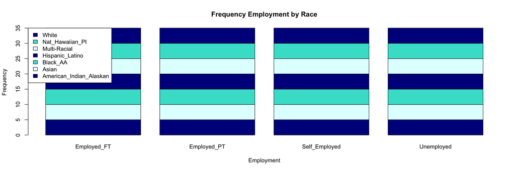

### Examine variablity across factor levels using box/scatter plots

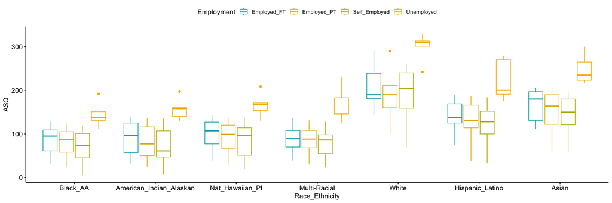

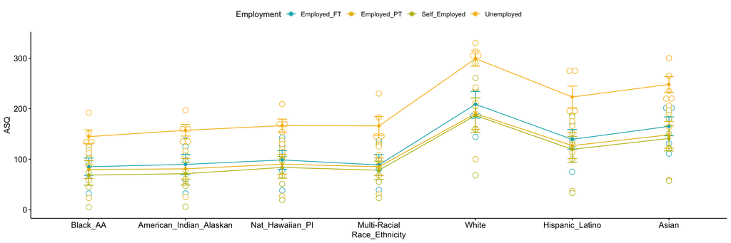

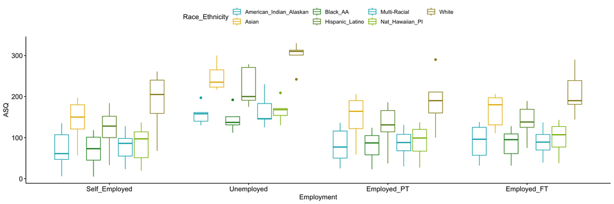

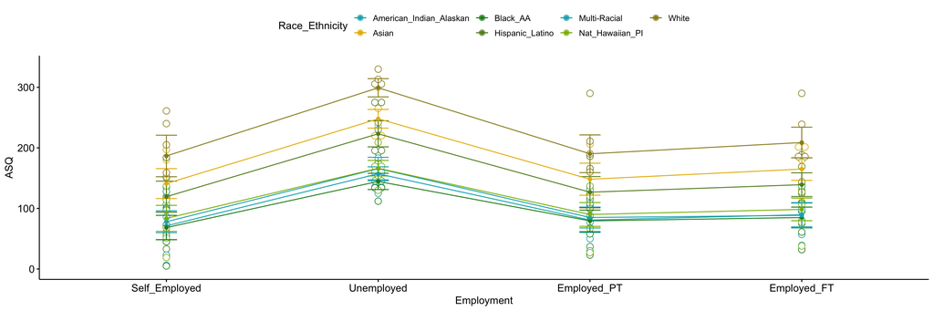

### Mean comparison model for race_ethnicity

Scatter plot graph with the means and standard error bars.

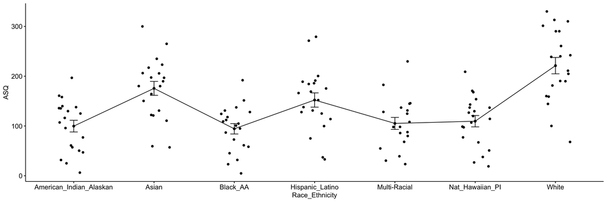

### Mean comparison model for employment

Scatter plot graph with the means and standard error bars.

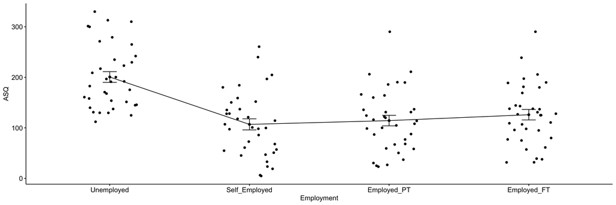

# Step 2: Running the 2-way ANOVA

```r
project_2way <- aov(ASQ ~ Race_Ethnicity + Employment + Race_Ethnicity:Employment, data = project_data)

summary(project_2way)
```

```
##                            Df Sum Sq Mean Sq F value   Pr(>F)
## Race_Ethnicity              6 274591   45765  20.607 4.22e-16 ***
## Employment                  3 196250   65417  29.456 4.37e-14 ***
## Race_Ethnicity:Employment  18   4606     256   0.115        1
## Residuals                 111 246513    2221
## ---
## Signif. codes:  0 '***' 0.001 '**' 0.01 '*' 0.05 '.' 0.1 ' ' 1
## 1 observation deleted due to missingness
```

# Step 3: Testing Simple Main Effects for Our Factors

Using one way anovas, we test simple main effect of race_ethnicity at all levels of our Employment factor(“Unemployed”,“Self_Employed”,“Employed_PT”,“Employed_FT”)

## Simple Main Effect for Race_Ethnicity

### Simple Main Effect for Race_Ethnicity for Unemployed-only level

```r
unemployed_data <- subset(project_data, Employment == "Unemployed")
unemployed_anova <- aov(ASQ ~ Race_Ethnicity, data = unemployed_data)
summary(unemployed_anova)
```

```
##                Df Sum Sq Mean Sq F value   Pr(>F)
## Race_Ethnicity  6  99399   16566   13.24 4.57e-07 ***
## Residuals      28  35028    1251
## ---
## Signif. codes:  0 '***' 0.001 '**' 0.01 '*' 0.05 '.' 0.1 ' ' 1
```

```r
TukeyHSD(unemployed_anova)
```

```
##   Tukey multiple comparisons of means
##     95% family-wise confidence level
##
## Fit: aov(formula = ASQ ~ Race_Ethnicity, data = unemployed_data)
##
## $Race_Ethnicity
##                                           diff         lwr       upr     p adj
## Asian-American_Indian_Alaskan             90.8   19.841053 161.75895 0.0058582
## Black_AA-American_Indian_Alaskan         -12.6  -83.558947  58.35895 0.9973819
## Hispanic_Latino-American_Indian_Alaskan   66.0   -4.958947 136.95895 0.0811646
## Multi-Racial-American_Indian_Alaskan       8.6  -62.358947  79.55895 0.9996991
## Nat_Hawaiian_PI-American_Indian_Alaskan    9.2  -61.758947  80.15895 0.9995563
## White-American_Indian_Alaskan            142.0   71.041053 212.95895 0.0000138
## Black_AA-Asian                          -103.4 -174.358947 -32.44105 0.0013551
## Hispanic_Latino-Asian                    -24.8  -95.758947  46.15895 0.9201481
## Multi-Racial-Asian                       -82.2 -153.158947 -11.24105 0.0153280
## Nat_Hawaiian_PI-Asian                    -81.6 -152.558947 -10.64105 0.0163660
## White-Asian                               51.2  -19.758947 122.15895 0.2841489
## Hispanic_Latino-Black_AA                  78.6    7.641053 149.55895 0.0226271
## Multi-Racial-Black_AA                     21.2  -49.758947  92.15895 0.9609489
## Nat_Hawaiian_PI-Black_AA                  21.8  -49.158947  92.75895 0.9554528
## White-Black_AA                           154.6   83.641053 225.55895 0.0000032
## Multi-Racial-Hispanic_Latino             -57.4 -128.358947  13.55895 0.1750204
## Nat_Hawaiian_PI-Hispanic_Latino          -56.8 -127.758947  14.15895 0.1839330
## White-Hispanic_Latino                     76.0    5.041053 146.95895 0.0298000
## Nat_Hawaiian_PI-Multi-Racial               0.6  -70.358947  71.55895 1.0000000
## White-Multi-Racial                       133.4   62.441053 204.35895 0.0000381
## White-Nat_Hawaiian_PI                    132.8   61.841053 203.75895 0.0000409
```

**The Race_Ethnicity simple main effect was significant indicating that at least twomeans differ across the Race_Ethnicity groups within the unemployed employment level. since we have 7 levels in Race_Ethnicity, we ran a post-hoc comparison and found the following pairs with sgnificant differences: Asian-American_Indian_Alaskan, White-American_Indian_Alaskan, Black_AA-Asian,Multi-Racial-Asian, Nat_Hawaiian_PI-Asian, Hispanic_Latino-Black_AA, White-Black_AA, White-Hispanic_Latino, White-Multi-Racial, White-Nat_Hawaiian_PI**

### Simple Main Effect for Race_Ethnicity for Selfemployed-only level

```r
selfemployed_data <- subset(project_data, Employment == "Self_Employed")
selfemployed_anova <- aov(ASQ ~ Race_Ethnicity, data = selfemployed_data)
summary(selfemployed_anova)
```

```
##                Df Sum Sq Mean Sq F value Pr(>F)
## Race_Ethnicity  6  59030    9838   3.318 0.0135 *
## Residuals      28  83012    2965
## ---
## Signif. codes:  0 '***' 0.001 '**' 0.01 '*' 0.05 '.' 0.1 ' ' 1
```

```r
TukeyHSD(selfemployed_anova)
```

```
##   Tukey multiple comparisons of means
##     95% family-wise confidence level
##
## Fit: aov(formula = ASQ ~ Race_Ethnicity, data = selfemployed_data)
##
## $Race_Ethnicity
##                                          diff          lwr      upr     p adj
## Asian-American_Indian_Alaskan            69.8  -39.4374016 179.0374 0.4211055
## Black_AA-American_Indian_Alaskan         -2.8 -112.0374016 106.4374 1.0000000
## Hispanic_Latino-American_Indian_Alaskan  48.2  -61.0374016 157.4374 0.7973831
## Multi-Racial-American_Indian_Alaskan      6.8 -102.4374016 116.0374 0.9999940
## Nat_Hawaiian_PI-American_Indian_Alaskan  12.4  -96.8374016 121.6374 0.9997940
## White-American_Indian_Alaskan           115.4    6.1625984 224.6374 0.0332120
## Black_AA-Asian                          -72.6 -181.8374016  36.6374 0.3754228
## Hispanic_Latino-Asian                   -21.6 -130.8374016  87.6374 0.9952832
## Multi-Racial-Asian                      -63.0 -172.2374016  46.2374 0.5404636
## Nat_Hawaiian_PI-Asian                   -57.4 -166.6374016  51.8374 0.6422828
## White-Asian                              45.6  -63.6374016 154.8374 0.8349490
## Hispanic_Latino-Black_AA                 51.0  -58.2374016 160.2374 0.7532471
## Multi-Racial-Black_AA                     9.6  -99.6374016 118.8374 0.9999538
## Nat_Hawaiian_PI-Black_AA                 15.2  -94.0374016 124.4374 0.9993351
## White-Black_AA                          118.2    8.9625984 227.4374 0.0274500
## Multi-Racial-Hispanic_Latino            -41.4 -150.6374016  67.8374 0.8874278
## Nat_Hawaiian_PI-Hispanic_Latino         -35.8 -145.0374016  73.4374 0.9399999
## White-Hispanic_Latino                    67.2  -42.0374016 176.4374 0.4655921
## Nat_Hawaiian_PI-Multi-Racial              5.6 -103.6374016 114.8374 0.9999981
## White-Multi-Racial                      108.6   -0.6374016 217.8374 0.0521158
## White-Nat_Hawaiian_PI                   103.0   -6.2374016 212.2374 0.0744314
```

**The Race_Ethnicity simple main effect was significant indicating that at least two means differ across the Race_Ethnicity groups within the self-employed employment level. We ran a post-hoc comparison and found the following pairs with significant differences: White-American_Indian_Alaskan, White-Black_AA**

### Simple Main Effect for Race_Ethnicity for Part Time employed-only level

```r
employedpt_data <- subset(project_data, Employment == "Employed_PT")
employedpt_anova <- aov(ASQ ~ Race_Ethnicity, data = employedpt_data)
summary(employedpt_anova)
```

```
##                Df Sum Sq Mean Sq F value Pr(>F)
## Race_Ethnicity  6  54277    9046   3.374 0.0125 *
## Residuals      28  75068    2681
## ---
## Signif. codes:  0 '***' 0.001 '**' 0.01 '*' 0.05 '.' 0.1 ' ' 1
```

```r
TukeyHSD(employedpt_anova)
```

```
##   Tukey multiple comparisons of means
##     95% family-wise confidence level
##
## Fit: aov(formula = ASQ ~ Race_Ethnicity, data = employedpt_data)
##
## $Race_Ethnicity
##                                          diff         lwr       upr     p adj
## Asian-American_Indian_Alaskan            67.4  -36.479667 171.27967 0.4032481
## Black_AA-American_Indian_Alaskan         -1.4 -105.279667 102.47967 1.0000000
## Hispanic_Latino-American_Indian_Alaskan  46.0  -57.879667 149.87967 0.7947673
## Multi-Racial-American_Indian_Alaskan      4.2  -99.679667 108.07967 0.9999995
## Nat_Hawaiian_PI-American_Indian_Alaskan   9.2  -94.679667 113.07967 0.9999517
## White-American_Indian_Alaskan           109.4    5.520333 213.27967 0.0340232
## Black_AA-Asian                          -68.8 -172.679667  35.07967 0.3794208
## Hispanic_Latino-Asian                   -21.4 -125.279667  82.47967 0.9941163
## Multi-Racial-Asian                      -63.2 -167.079667  40.67967 0.4785624
## Nat_Hawaiian_PI-Asian                   -58.2 -162.079667  45.67967 0.5731644
## White-Asian                              42.0  -61.879667 145.87967 0.8540625
## Hispanic_Latino-Black_AA                 47.4  -56.479667 151.27967 0.7718754
## Multi-Racial-Black_AA                     5.6  -98.279667 109.47967 0.9999974
## Nat_Hawaiian_PI-Black_AA                 10.6  -93.279667 114.47967 0.9998892
## White-Black_AA                          110.8    6.920333 214.67967 0.0307960
## Multi-Racial-Hispanic_Latino            -41.8 -145.679667  62.07967 0.8567644
## Nat_Hawaiian_PI-Hispanic_Latino         -36.8 -140.679667  67.07967 0.9153243
## White-Hispanic_Latino                    63.4  -40.479667 167.27967 0.4748660
## Nat_Hawaiian_PI-Multi-Racial              5.0  -98.879667 108.87967 0.9999987
## White-Multi-Racial                      105.2    1.320333 209.07967 0.0456571
## White-Nat_Hawaiian_PI                   100.2   -3.679667 204.07967 0.0641299
```

**The Race_Ethnicity simple main effect was significant indicating that at least two means differ across the Race_Ethnicity groups within the parttime-employed employment level. We ran a post-hoc comparison and found the following pairs with significant differences: White-American_Indian_Alaskan, White-Black_AA, White-Multi-Racial**

### Simple Main Effect for Race_Ethnicity for Full Time employed-only level

```r
employedft_data <- subset(project_data, Employment == "Employed_FT")
employedft_anova <- aov(ASQ ~ Race_Ethnicity, data = employedft_data)
summary(employedft_anova)
```

```
##                Df Sum Sq Mean Sq F value  Pr(>F)
## Race_Ethnicity  6  67219   11203   5.664 0.00065 ***
## Residuals      27  53405    1978
## ---
## Signif. codes:  0 '***' 0.001 '**' 0.01 '*' 0.05 '.' 0.1 ' ' 1
## 1 observation deleted due to missingness
```

```r
TukeyHSD(employedft_anova)
```

```
##   Tukey multiple comparisons of means
##     95% family-wise confidence level
##
## Fit: aov(formula = ASQ ~ Race_Ethnicity, data = employedft_data)
##
## $Race_Ethnicity
##                                          diff        lwr        upr     p adj
## Asian-American_Indian_Alaskan            75.4  -14.06862 164.868623 0.1419994
## Black_AA-American_Indian_Alaskan         -4.6  -94.06862  84.868623 0.9999980
## Hispanic_Latino-American_Indian_Alaskan  49.6  -39.86862 139.068623 0.5821743
## Multi-Racial-American_Indian_Alaskan     -1.1  -95.99581  93.795805 1.0000000
## Nat_Hawaiian_PI-American_Indian_Alaskan   8.8  -80.66862  98.268623 0.9999086
## White-American_Indian_Alaskan           119.2   29.73138 208.668623 0.0039046
## Black_AA-Asian                          -80.0 -169.46862   9.468623 0.1026132
## Hispanic_Latino-Asian                   -25.8 -115.26862  63.668623 0.9664846
## Multi-Racial-Asian                      -76.5 -171.39581  18.395805 0.1769409
## Nat_Hawaiian_PI-Asian                   -66.6 -156.06862  22.868623 0.2504294
## White-Asian                              43.8  -45.66862 133.268623 0.7090875
## Hispanic_Latino-Black_AA                 54.2  -35.26862 143.668623 0.4809950
## Multi-Racial-Black_AA                     3.5  -91.39581  98.395805 0.9999997
## Nat_Hawaiian_PI-Black_AA                 13.4  -76.06862 102.868623 0.9989681
## White-Black_AA                          123.8   34.33138 213.268623 0.0025698
## Multi-Racial-Hispanic_Latino            -50.7 -145.59581  44.195805 0.6221864
## Nat_Hawaiian_PI-Hispanic_Latino         -40.8 -130.26862  48.668623 0.7700677
## White-Hispanic_Latino                    69.6  -19.86862 159.068623 0.2081858
## Nat_Hawaiian_PI-Multi-Racial              9.9  -84.99581 104.795805 0.9998711
## White-Multi-Racial                      120.3   25.40419 215.195805 0.0065633
## White-Nat_Hawaiian_PI                   110.4   20.93138 199.868623 0.0085801
```

**The Race_Ethnicity simple main effect was significant indicating that at least two means differ across the Race_Ethnicity groups within the fulltime-employed employment level. We ran a post-hoc comparison and found the following pairs with significant differences: White-American_Indian_Alaskan, White-Black_AA, White-Multi-Racial, White-Nat_Hawaiian_PI**

### Simple Main Effect for Race_Ethnicity Visual

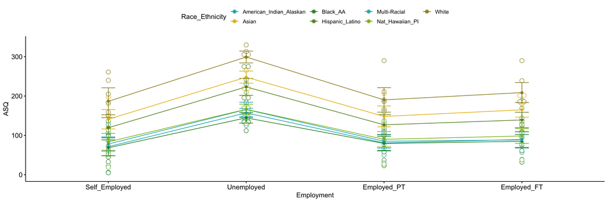